# Retail

Ayodeji Akiwowo

31 October 2017

## Big Mart Sales

**Problem Statement**

*A retail company “ABC Private Limited” wants to understand the customer purchase behaviour* *(specifically, purchase amount) against various products of different categories. They have shared* *purchase summary of various customers for selected high volume products from last month.* *The data set also contains customer demographics (age, gender, marital status, city_type,* *stay_in_current_city), product details (product_id and product category) and Total purchase_amount from* *last month.* *Now, they want to build a model to predict the purchase amount of customer against various products* *which will help them to create personalized offer for customers against different products.*

In summary, we want to see if we can build a model which will predict amount spent by customers (Purchase Amount) on various products using their purchase history. To achieve this aim, we will follow the standard Datascience lifecyle (see figure 1)

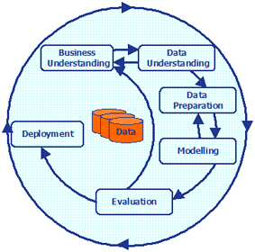

figure 1

## Data Understanding

**Data**

Variables in dataset

| Variable | Definition |
| --- | --- |
| User_ID | User ID |
| Product_ID | Product ID |
| Gender | Sex of User |
| Age | Age in bins |
| Occupation | Occupation (Masked |
| City_Category | Category of the City (A,B,C) |
| Stay_In_Current_City_Years | Number of Years stay in current city |
| Marital_Status | Marital Status |
| Product_Category_1 | Product Category (Masked) |
| Product_Category_2 | Product may belong to other category also (Masked) |
| Product_Category_3 | Product may belong to other category also (Masked) |
| Purchase | Purchase Amount (Target Variable) |

Two datasets were provided for the hack - the training and test datasets with 12 and 11 variables respectively. The “Purchase Amount” is the target variable and is hence missing from the test data.

**Data structure:**

```r
str(train)
```

```
## 'data.frame':    550068 obs. of  12 variables:
##  $ User_ID                   : int  1000001 1000001 1000001 1000001 1000002 1000003 1000004 1000004 1000004 1000005 ...
##  $ Product_ID                : chr  "P00069042" "P00248942" "P00087842" "P00085442" ...
##  $ Gender                    : chr  "F" "F" "F" "F" ...
##  $ Age                       : chr  "0-17" "0-17" "0-17" "0-17" ...
##  $ Occupation                : int  10 10 10 10 16 15 7 7 7 20 ...
##  $ City_Category             : chr  "A" "A" "A" "A" ...
##  $ Stay_In_Current_City_Years: chr  "2" "2" "2" "2" ...
##  $ Marital_Status            : int  0 0 0 0 0 0 1 1 1 1 ...
##  $ Product_Category_1        : int  3 1 12 12 8 1 1 1 1 8 ...
##  $ Product_Category_2        : int  NA 6 NA 14 NA 2 8 15 16 NA ...
##  $ Product_Category_3        : int  NA 14 NA NA NA NA 17 NA NA NA ...
##  $ Purchase                  : int  8370 15200 1422 1057 7969 15227 19215 15854 15686 7871 ...
```

```r
str(test)
```

```
## 'data.frame':    233599 obs. of  11 variables:
##  $ User_ID                   : int  1000004 1000009 1000010 1000010 1000011 1000013 1000013 1000013 1000015 1000022 ...
##  $ Product_ID                : chr  "P00128942" "P00113442" "P00288442" "P00145342" ...
##  $ Gender                    : chr  "M" "M" "F" "F" ...
##  $ Age                       : chr  "46-50" "26-35" "36-45" "36-45" ...
##  $ Occupation                : int  7 17 1 1 1 1 1 1 7 15 ...
##  $ City_Category             : chr  "B" "C" "B" "B" ...
##  $ Stay_In_Current_City_Years: chr  "2" "0" "4+" "4+" ...
##  $ Marital_Status            : int  1 0 1 1 0 1 1 1 0 0 ...
##  $ Product_Category_1        : int  1 3 5 4 4 2 1 2 10 5 ...
##  $ Product_Category_2        : int  11 5 14 9 5 3 11 4 13 14 ...
##  $ Product_Category_3        : int  NA NA NA NA 12 15 15 9 16 NA ...
```

The training and test datasets are read into R and stored as train (550068 rows) and test (233599 rows). The summary statistics below show that for the training data, asides from Product Category 2 and Product Category 3, none of the variables have any missing values. The missing product categories is not unexpected as the data dictionary has explained that a product may belong to more than one category. Since Product category 1 has no NA, we may safely assume that the product belongs to category 1 if both categories 2 and 3 are NAs.

## Data Preparation

```r
train$User_ID <- as.factor(train$User_ID)
test$User_ID <- as.factor(test$User_ID)

train$Product_ID <- as.factor(train$Product_ID)
test$Product_ID <- as.factor(test$Product_ID)

train$Gender <- as.factor(train$Gender)
test$Gender <- as.factor(test$Gender)

train$City_Category <- as.factor(train$City_Category)
test$City_Category <- as.factor(test$City_Category)

train$Marital_Status <- as.factor(train$Marital_Status)
test$Marital_Status <- as.factor(test$Marital_Status)

train$Occupation <- as.factor(train$Occupation)
test$Occupation <- as.factor(test$Occupation)

train$Product_Category_1 <- as.factor(train$Product_Category_1)
test$Product_Category_1 <- as.factor(test$Product_Category_1)

train$Product_Category_2 <- as.factor(train$Product_Category_2)
test$Product_Category_2 <- as.factor(test$Product_Category_2)

train$Product_Category_3 <- as.factor(train$Product_Category_3)
test$Product_Category_3 <- as.factor(test$Product_Category_3)
```

**Summary statistics:**

```r
n_distinct(train$User_ID)
```

```
## [1] 5891
```

```r
n_distinct(test$User_ID)
```

```
## [1] 5891
```

```r
n_distinct(train$Product_ID)
```

```
## [1] 3631
```

```r
n_distinct(test$Product_ID)
```

```
## [1] 3491
```

```r
sum(is.na(train$User_ID))
```

```
## [1] 0
```

```r
sum(is.na(test$User_ID))
```

```
## [1] 0
```

```r
sum(is.na(train$Product_ID))
```

```
## [1] 0
```

```r
sum(is.na(test$Product_ID))
```

```
## [1] 0
```

The number of unique users is evenly distributed in the train and test datasets (5891). In addition, there are 3631 and 3491 unique products in the train and test datasets respectively. There are no missing valuesfor users and products

```r
summary(train)
```

```
##     User_ID           Product_ID     Gender         Age
##  1001680:  1026   P00265242:  1880   F:135809   Length:550068
##  1004277:   979   P00025442:  1615   M:414259   Class :character
##  1001941:   898   P00110742:  1612              Mode  :character
##  1001181:   862   P00112142:  1562
##  1000889:   823   P00057642:  1470
##  1003618:   767   P00184942:  1440
##  (Other):544713   (Other)  :540489
##    Occupation     City_Category Stay_In_Current_City_Years Marital_Status
##  4      : 72308   A:147720      Length:550068              0:324731
##  0      : 69638   B:231173      Class :character           1:225337
##  7      : 59133   C:171175      Mode  :character
##  1      : 47426
##  17     : 40043
##  20     : 33562
##  (Other):227958
##  Product_Category_1 Product_Category_2 Product_Category_3    Purchase
##  5      :150933     8      : 64088     16     : 32636     Min.   :   12
##  1      :140378     14     : 55108     15     : 28013     1st Qu.: 5823
##  8      :113925     2      : 49217     14     : 18428     Median : 8047
##  11     : 24287     16     : 43255     17     : 16702     Mean   : 9264
##  2      : 23864     15     : 37855     5      : 16658     3rd Qu.:12054
##  6      : 20466     (Other):126907     (Other): 54384     Max.   :23961
##  (Other): 76215     NA's   :173638     NA's   :383247
```

```r
summary(test)
```

```
##     User_ID           Product_ID     Gender         Age
##  1001680:   442   P00265242:   829   F: 57827   Length:233599
##  1004277:   405   P00112142:   717   M:175772   Class :character
##  1001941:   388   P00025442:   695              Mode  :character
##  1000889:   381   P00110742:   680
##  1001181:   368   P00046742:   646
##  1004344:   338   P00184942:   626
##  (Other):231277   (Other)  :229406
##    Occupation    City_Category Stay_In_Current_City_Years Marital_Status
##  4      :30778   A:62524       Length:233599              0:137807
##  0      :29212   B:98566       Class :character           1: 95792
##  7      :24994   C:72509       Mode  :character
##  1      :20261
##  17     :17375
##  20     :14278
##  (Other):96701
##  Product_Category_1 Product_Category_2 Product_Category_3
##  5      :65017      8      :27229      16     : 13833
##  1      :60321      14     :23726      15     : 11955
##  8      :48369      2      :21281      14     :  7855
##  2      :10192      16     :18432      5      :  7141
##  11     :10153      15     :16259      17     :  7116
##  6      : 8860      (Other):54328      (Other): 23137
##  (Other):30687      NA's   :72344      NA's   :162562
```

**Define Hypotheses**

1. **Product:** The lower the cost of a product, the higher the number of purchases (count).
2. **Gender:** Women spend more on purchases than men
3. **Occupation:** Certain types of occupations will have higher purchases
4. **Age:** The older you are, the less you purchase (count and amount spent)
5. **Stay in current city:** The longer you stay in the city, the more purchases you make
6. **Product Category:** The category a product belongs to determines which Gender will have higher purchase (count)
7. **Product Category:** The category a product belongs to determines which Age band will have higher purchase (count)

### Exploratory Data Analysis

Before exploring further, I combined both the train and datasets in order to have a broader view of the dataset. However, I created a new variable “Source” which acts as label for the two sets and added a variable Purchase for the test set to allow for rbinding. NAs are assigned to this new variable in the test data.

```r
train$source <- "train"
test$source <- "test"
test$Purchase <- NA
```

```r
df <- rbind(train, test)
```

```r
summary(df)
```

```
##     User_ID           Product_ID     Gender         Age
##  1001680:  1468   P00265242:  2709   F:193636   Length:783667
##  1004277:  1384   P00025442:  2310   M:590031   Class :character
##  1001941:  1286   P00110742:  2292              Mode  :character
##  1001181:  1230   P00112142:  2279
##  1000889:  1204   P00046742:  2084
##  1003618:  1079   P00057642:  2079
##  (Other):776016   (Other)  :769914
##    Occupation     City_Category Stay_In_Current_City_Years Marital_Status
##  4      :103086   A:210244      Length:783667              0:462538
##  0      : 98850   B:329739      Class :character           1:321129
##  7      : 84127   C:243684      Mode  :character
##  1      : 67687
##  17     : 57418
##  20     : 47840
##  (Other):324659
##  Product_Category_1 Product_Category_2 Product_Category_3    Purchase
##  5      :215950     8      : 91317     16     : 46469     Min.   :   12
##  1      :200699     14     : 78834     15     : 39968     1st Qu.: 5823
##  8      :162294     2      : 70498     14     : 26283     Median : 8047
##  11     : 34440     16     : 61687     17     : 23818     Mean   : 9264
##  2      : 34056     15     : 54114     5      : 23799     3rd Qu.:12054
##  6      : 29326     (Other):181235     (Other): 77521     Max.   :23961
##  (Other):106902     NA's   :245982     NA's   :545809     NA's   :233599
##     source
##  Length:783667
##  Class :character
##  Mode  :character
##
##
##
##
```

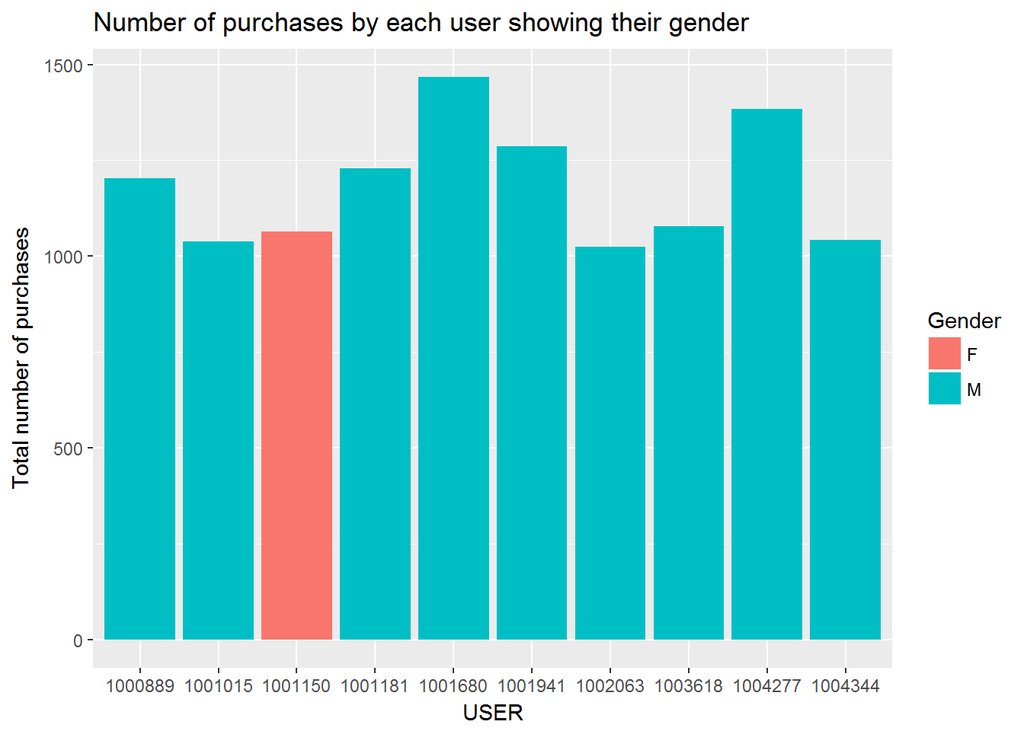

```r
df %>% group_by(User_ID) %>%
  summarize(tot = n(), gend = first(Gender)) %>%
  arrange(desc(tot)) %>%
  head(10) %>%
  ggplot(aes(User_ID, tot, fill = gend)) + geom_bar(stat = "identity") +
  labs(x = "USER", y = "Total number of purchases", fill = "Gender") +
  ggtitle("Number of purchases by each user showing their gender")
```

The plot above shows the top 10 users in terms of counts for the dataset. User 1001680 has the highest number of purchases (1468). We can also see that from the top 10 purchasers, there are 9 males and 1 female. To have a wider view, we will extend this to the top 20 in the next plot.

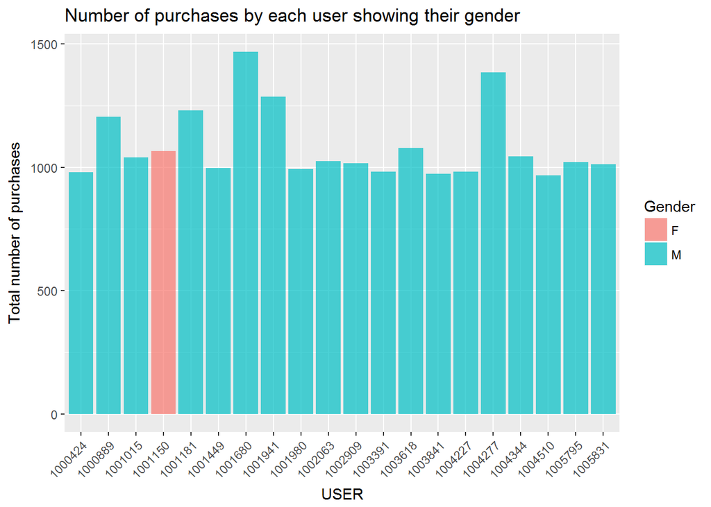

```r
df %>% group_by(User_ID) %>%
  summarize(tot = n(), gend = first(Gender)) %>%
  arrange(desc(tot)) %>%
  head(20) %>%
  ggplot(aes(User_ID, tot, fill = gend)) + geom_bar(alpha = 0.7, stat = "identity") +
  labs(x = "USER", y = "Total number of purchases", fill = "Gender") +
  ggtitle("Number of purchases by each user showing their gender") +
  theme(axis.text.x = element_text(angle = 45, vjust = 1, hjust = 1))
```

Again, there is just one female user in the top 20. This is somewhat not accepting our second hypothesis of women spending more on shopping than men. To confirm this, let’s look at the gender variable in terms of the number of purchases and also in terms of how much was spent on purchases

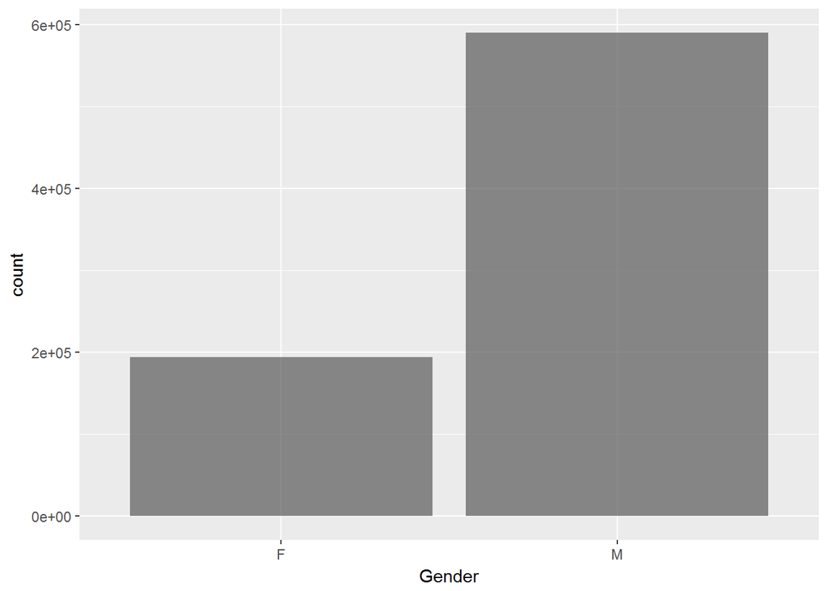

```r
df %>% ggplot(aes(Gender)) + geom_bar(alpha = 0.7)
```

In the first instance, from the dataset, there are more men than women. As this is a selected dataset, it will be difficult to make bold conclusions as we do not know how the data was selected. The next step is to look at the total amount spent by both men and females. Remember that only the “train” labeled data have purchase amount linked to them. Hence we will restrict our totals to this section only.

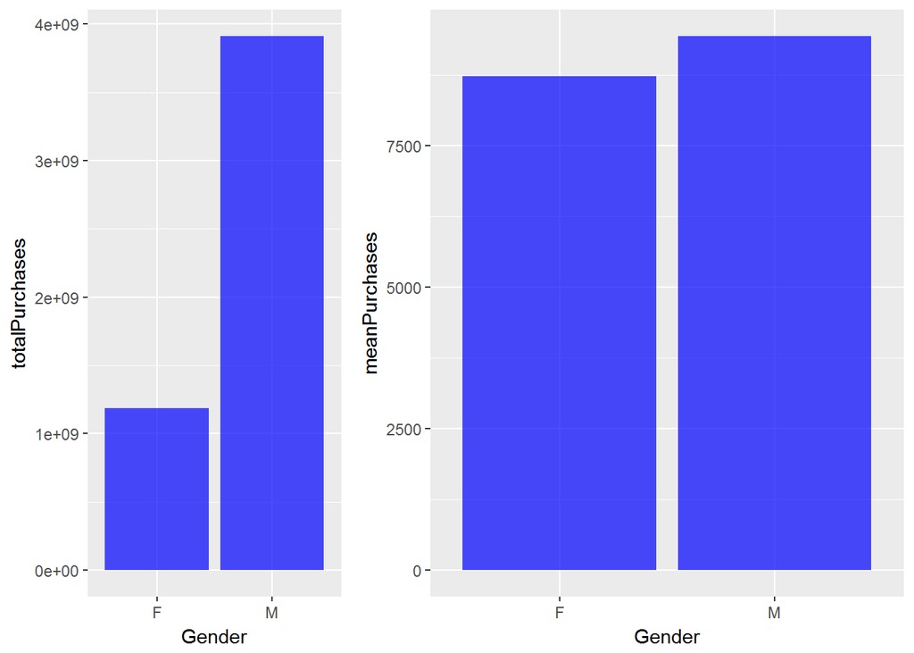

```r
p1 <- df %>% filter(source == "train") %>%
  group_by(Gender) %>%
  summarize(totalPurchases = sum(as.numeric(Purchase), na.rm = TRUE),
            count = n()) %>%
  ggplot() + geom_bar(fill = "blue", alpha = 0.7, aes(Gender, totalPurchases), stat = "identity")

p2 <- df %>% filter(source == "train") %>%
  group_by(Gender) %>%
  summarize(meanPurchases = mean(as.numeric(Purchase), na.rm = TRUE),
            count = n()) %>%
  ggplot() + geom_bar(fill = "blue", alpha = 0.7, aes(Gender, meanPurchases), stat = "identity")


grid.arrange(p1, p2, widths = c(0.5, 0.8))
```

In terms of the total purchases, there’s a significant difference in the amount of money spent by males and females. This is most likely due to the large disparity in the number of men and women purchases in the data. A better way to look at purchases is to view it from an average point of view. In essence, how much does a person spend per visit. This is reflected in the second plot (right) showing the meanPurchases. This shows that although the men still lead in terms of purchases, the difference is not that much from the women. However, this means that our second hypothesis is not accepted.

**Occupation** The variable “Occupation” defines the occupation of the customers. The real occupation is masked so we only know they are from group 0 to 20. We do not know what these numbers stand for except that they refer to different occupations.

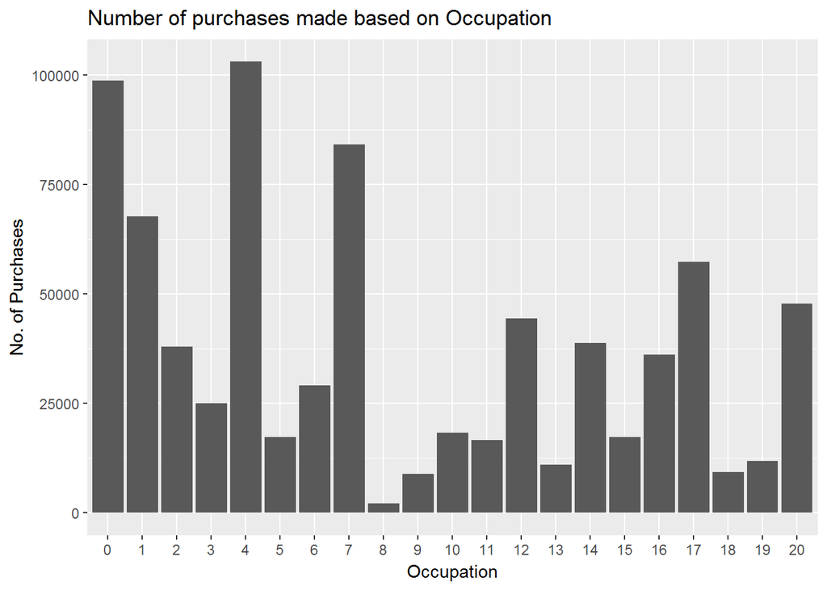

```r
df %>% group_by(Occupation) %>%
  summarize(Occ = n()) %>%
  ggplot(aes(Occupation, Occ)) + geom_bar(stat = "identity") + labs(x = "Occupation", y = "No. of Purchases", title = "Number of purchases made based on Occupation")
```

Occupation 4 has the highest number of purchases followed by Occupation 0 and then 7. This means that people with occupation 4 made the highest number of purchases at the store. On the other hand, people with Occupation 8 made the least number of purchases. How do these purchases compare with sales?

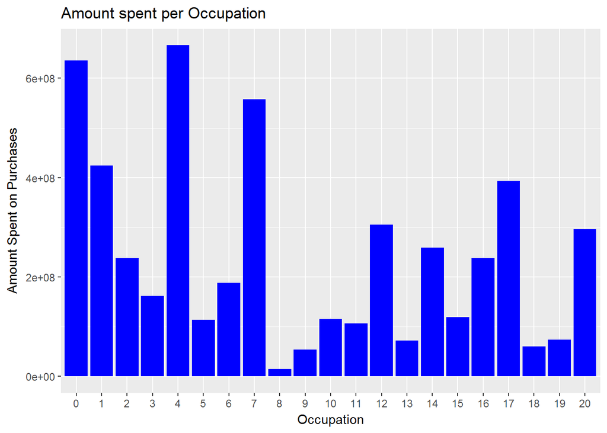

```r
df %>% filter(source == "train") %>%
  group_by(Occupation) %>%
  summarize(sumOcc = sum(Purchase), count = n()) %>%
  ggplot(aes(Occupation,sumOcc)) + geom_bar(fill = "blue", stat = "identity") +
  labs(x = "Occupation", y = "Amount Spent on Purchases", title = "Amount spent per Occupation")
```

There are no suprises in terms of the amount spent compared with the number of purchases. Occupation 4 still leads (666244484) followed by Occupation 0 (635406958). This is due to the large differences between the count of purchases.

It is more insightful to compare based on average amount spent per purchase. This is shown in the next plot.

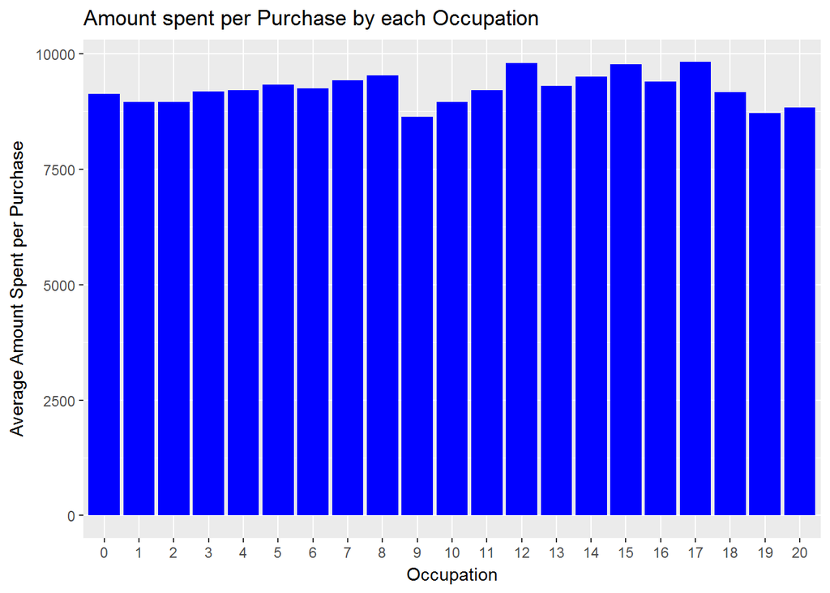

```r
df %>% filter(source == "train") %>%
  group_by(Occupation) %>%
  summarize(sumOcc = sum(Purchase), count = n(), mean1 = mean(Purchase)) %>%
  ggplot(aes(Occupation,mean1)) + geom_bar(fill = "blue", stat = "identity") +
  labs(x = "Occupation", y = "Average Amount Spent per Purchase", title = "Amount spent per Purchase by each Occupation")
```

This average aggregated plot highlights which occupation tends to spend more money per purchase. As can be seen, Occupation 12, 15 and 17’s money spent per purchase is close to 10000 which are the top 3 in this category. However, when compared to total amount spent on all purchases over this time period, occupation 12 and 15 don’t seem to do well even though they are willing to spend a lot of money on one purchase. It is therefore imperative for the company to spend time targeting this groups of customers.

The plot below shows the amount spent by gender per occupation. As mentioned earlier, seeing that men tend to spend more (per occupation) than women could be due to the fact that we have a very high difference between number of males compared to females in our data. That said, for some occupations like occupation 9, we see females spending more money than males. It is not surprising thatthere are a lot more women than men in this group as shown below.

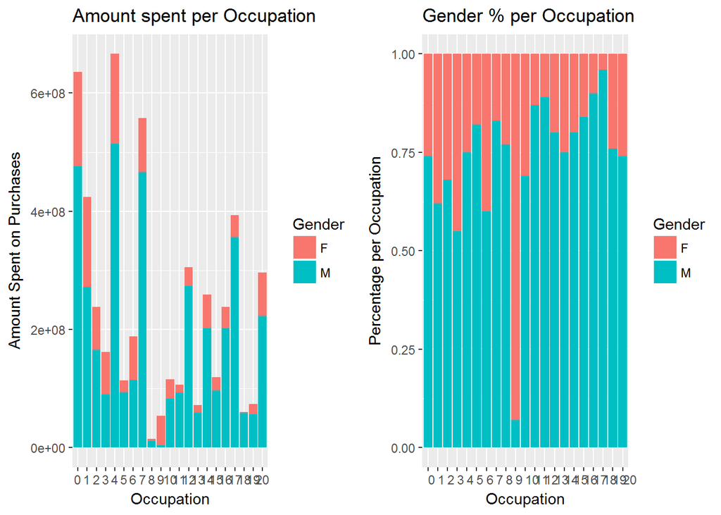

```r
a1 <- df %>% filter(source == "train") %>%
  group_by(Occupation, Gender) %>%
  summarize(sumOcc = sum(Purchase), count = n()) %>%
  ggplot(aes(Occupation,sumOcc, fill = Gender)) + geom_bar(stat = "identity") +
  labs(x = "Occupation", y = "Amount Spent on Purchases", title = "Amount spent per Occupation")

a2 <- df %>% group_by(Occupation, Gender) %>%
  summarize(n = n()) %>%
  mutate(freq = round(n / sum(n), 2)) %>%
  ggplot(aes(Occupation, freq, fill = Gender)) + geom_bar(stat = "identity") +
  labs(x = "Occupation", y = "Percentage per Occupation", title = "Gender % per Occupation") +
  theme(axis.text.x = element_text(angle = 0, vjust = 0, hjust = 0))

grid.arrange(a1, a2, widths = c(0.5, 0.5))
```

Summarising this section, our hypothesis is allowed i.e. certain types of occupations spend more money than others. However, on single purchases, there is not much difference in terms of what occupations buy (note: this is dependent on the price range of items at this retail company)

**Age**

```r
df$Age <- as.factor(df$Age)
```

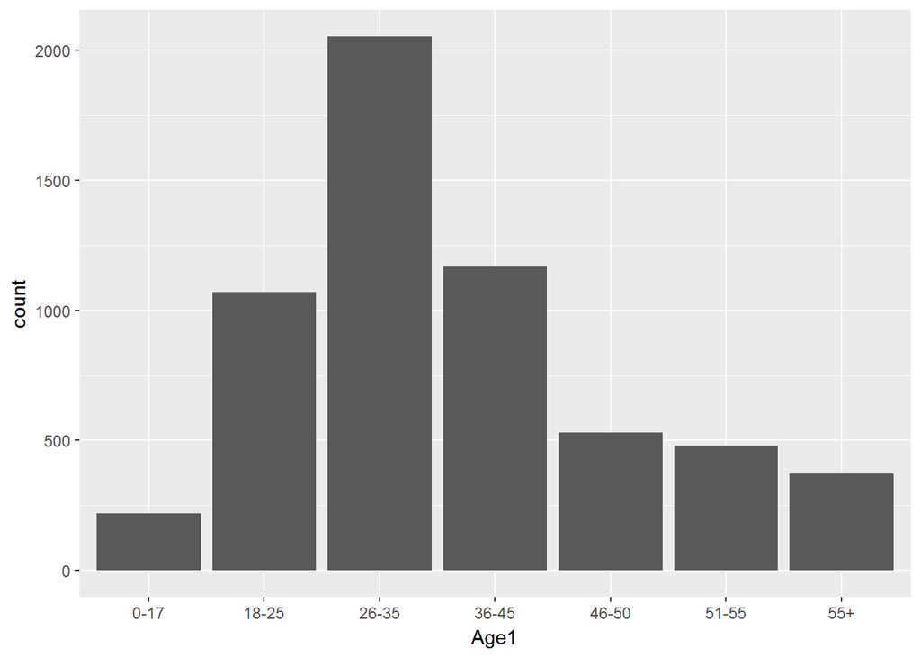

```r
df %>% filter(source == "train") %>%
  group_by(User_ID, Age) %>%
  summarize(Age1 = first(Age)) %>%
  ggplot(aes(Age1)) + geom_bar()
```

Of the 5891 users in the training dataset, those in the 26 to 35 years old range form the highest population followed by 36-45 and 18-25 respectively. The 0-17 for the least population.

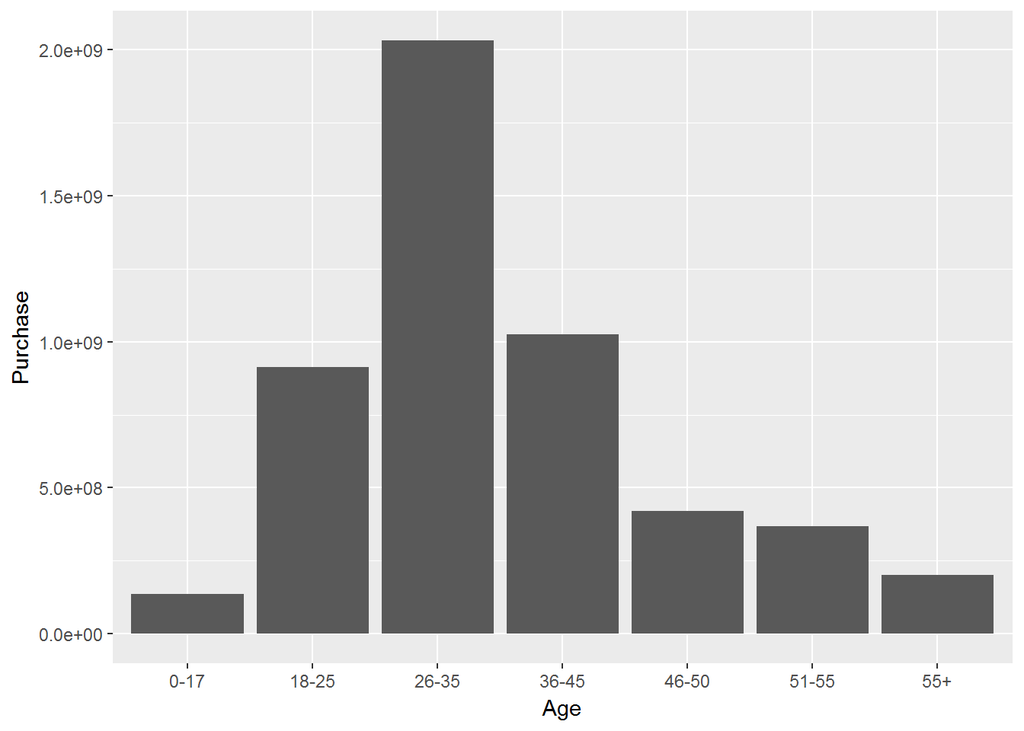

```r
df %>% filter(source == "train") %>%
  ggplot(aes(Age, Purchase)) + geom_bar(stat = "identity")
```

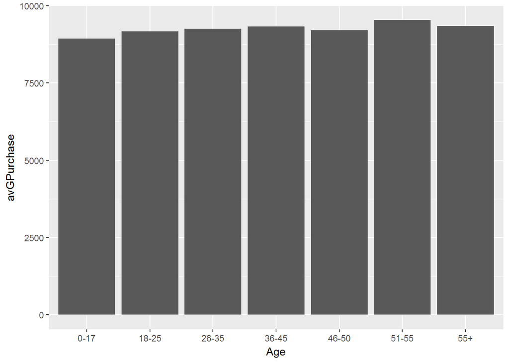

```r
df %>% filter(source == "train") %>%
  group_by(Age) %>%
  summarize(count = n(), avGPurchase = mean(Purchase)) %>%
  ggplot(aes(Age, avGPurchase)) + geom_bar(stat = "identity")
```

Average purchases

*Products* Which products are Popular?